# 13_expanding_20_and_30_years

Joanna Schroeder

## Create the sequence objects

In the previous analysis, we looked at ten years of a career after the last O*NET 55 job.* We filtered out veterans without valid start and end dates (5,185 sample) * We did not filter out retirement/exit of the workforce within the ten years.

Our definition of retirement/exit of the workforce may not be accurate for everyone in the sample. A more accurate label for this state is "end of resume," so a veteran with two years of a civilian career followed by "retirement" could be retired or they could be looking for a new job. For meaningful analysis for this period of career history, we want to redefine our sample to exclude veterans without ten years of career history after they exit the military.

Criteria for inclusion: * Include left NAs (military transition unemployment) * Include gaps (civilian unemployment) * Exclude right NAs (this is not meaningful information its just the end of resume) * Complete cases for time span of interest (Complete 10, 20, or 30 year history)

```r
#import veteran job data
bg_vet_job <-read_csv("~/git/DSPG2020/career/data/04_bg_vet_job.csv")%>%
  mutate(year_enter_job_market = year(date_enter_job_market))%>%
  select(-noofjobs, -sector, -tenure) %>%
  group_by(id) %>%
  mutate(years_in_job_market = max(end_year) - (min(start_year)))
#colnames(bg_vet_job)

#veterans and the date they ended their last ONET 55 job
vet_endmilitary <- bg_vet_job%>%
  mutate(date_end_onet55 = if_else(is_onet55==T, enddate, as.Date(NA)))%>%
  filter(!is.na(date_end_onet55))%>%  #exluce people who don't have valid onet55 code
  select(id, date_end_onet55) %>%
  #keep the latest onet55 job
  group_by(id)%>%
  arrange(desc(date_end_onet55))%>%
  group_by(id)%>%
  distinct(id, .keep_all = TRUE)

bg_vet_job  <- inner_join(bg_vet_job, vet_endmilitary, by = "id")

## sequence data
bg_vet_job_seq <- bg_vet_job %>%
  select(id, end_year, onet_job_zone, startdate, enddate, job_duration_day, date_end_onet55, year_enter_job_market, years_in_job_market)%>%
  mutate(year_end_onet55 = year(date_end_onet55))%>%
  select(-year_enter_job_market)%>%
  filter(startdate >= date_end_onet55)%>% #find jobs that came after the date ended onet55 job
  filter(onet_job_zone != 55)  %>%  #filter out 55 jobs that have the same start and end date
  mutate(start_year = year(startdate))


check <- bg_vet_job_seq%>%
  mutate(year_until_first_job = start_year- year_end_onet55)%>%
  group_by(id)%>%
  summarize(years = min(year_until_first_job))

#ggplot(check, aes(x = years)) +
#  geom_histogram(binwidth = 1.4) +
#  labs(title = "", x = "years until first job")

#summary(check$years)

bg_vet_job_seq <- bg_vet_job_seq %>%
  mutate(years_after_onet55 = max(end_year) - year_end_onet55) %>%
  mutate(start_year = start_year - year_end_onet55 + 1)%>%  #transform from calender year to year start sequence analysis
  mutate(end_year = end_year - year_end_onet55 + 1) %>% #transform from calender year to year start sequence analysis
  select(id, start_year, end_year, onet_job_zone, years_after_onet55)%>%
  group_by(id)%>%
  arrange(desc(onet_job_zone))%>%
  group_by(id)%>%
  distinct(id, start_year, end_year, .keep_all = TRUE)
```

```r
#table(bg_vet_job_seq$onet_job_zone)
#length(unique(bg_vet_job_seq$id))  #confirm sample size match

#min(bg_vet_job_seq$start_year)
#max(bg_vet_job_seq$start_year)
```

```r
# object for ten years
career_sequence <- function(name = "sts_vet_ten", years) {
sts_vet <- bg_vet_job_seq %>%
  filter(years_after_onet55 >= years) %>%
  select(-years_after_onet55)

sts_vet <- as.matrix(sts_vet)
sts_vet <- as.data.frame(sts_vet)

sts_vet <- seqformat(sts_vet, from = "SPELL", to = "STS",
            id = "id",  begin = "start_year", end = "end_year",
            status = "onet_job_zone", process = FALSE)

vet.seq <- seqdef(sts_vet, left="Military transition unemployment", gaps="Civilian unemployment", right="DEL", cpal = c("#CBBEB5",  uva_color_palette[1], uva_color_palette[2],uva_color_palette[4],  uva_color_palette[6], uva_color_palette[9], "#CBBEB5", "#CBBEB5"))

# Filter out veterans who do not have a complete career in time period of interest
sts_vet <- vet.seq[, 1:years]

assign(name, sts_vet, envir = .GlobalEnv)
}

career_sequence("sts_vet_ten", 10)
career_sequence("sts_vet_twenty", 20)
career_sequence("sts_vet_thirty", 30)
```

# Sequence graphs and transition matricies

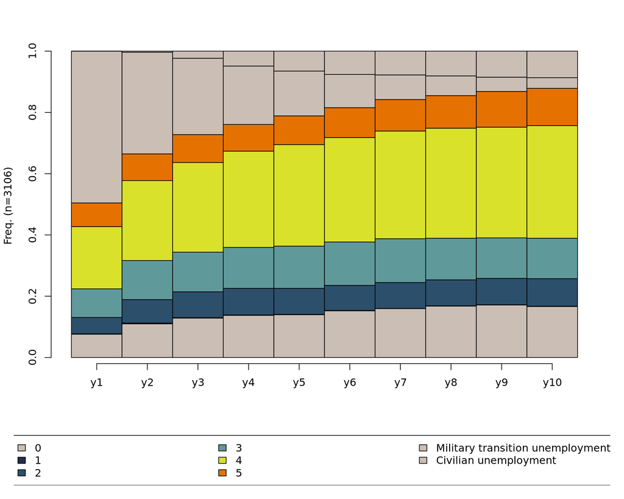

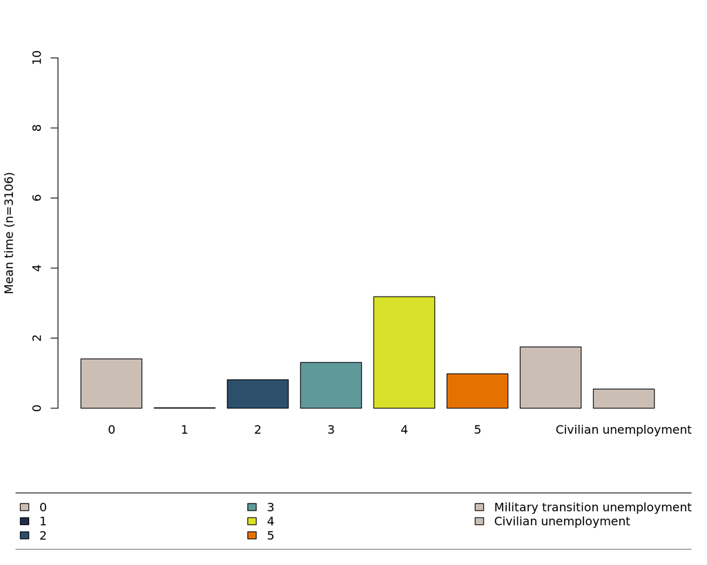

```r
## Function for creating a transition matrix
career_sequence_transition <- function(transition_name = "transition_ten", cost_name = "cost_ten", sequence_object) {
## Computing transition rates
#counts
transition_matrix <- seqtrate(sequence_object, weighted=FALSE, count=TRUE)
round(transition_matrix,2)
#standardize counts

#make the diagnal 0
diag(transition_matrix) = 0
round(transition_matrix,2)

#calculate rowsum
rowsum <- apply(transition_matrix, 1, sum)

#calculate percent
for(i in 1:nrow(transition_matrix)) {
  for (j in 1:ncol(transition_matrix)){
    transition_matrix[i,j] = transition_matrix[i,j]/rowsum[i]
  }
}

#code NAs as 0
for(j in 1:ncol(transition_matrix)){
      transition_matrix[8,j] = transition_matrix[8,j] = 0
}
transition_matrix <- round(transition_matrix,2)


#convert transition matrix to cost matrix
cost_matrix <- 2-transition_matrix
round(cost_matrix,2)

#make the diagnal 0
diag(cost_matrix) = 0
cost_matrix <- round(cost_matrix,2)

assign(transition_name, transition_matrix, envir = .GlobalEnv)
assign(cost_name, cost_matrix, envir = .GlobalEnv)
}

career_sequence_transition("transition_ten", "cost_ten", sts_vet_ten)
career_sequence_transition("transition_twenty", "cost_twenty", sts_vet_twenty)
career_sequence_transition("transition_thirty", "cost_thirty", sts_vet_thirty)

meant <- seqmeant(sts_vet_thirty)
meant <- as.data.frame(meant)
meant <- meant %>% rownames_to_column(var = "state")

## Function for creating sequence graphs
career_sequence_graphs <- function(sequence_object) {
seqdplot(sequence_object)
seqmtplot(sequence_object)

}


gg_transition_matrix <- function(tr, title) {
round(tr, 2)
transition.matrix.df <- as.data.frame(tr)
transition.matrix.df$startState <- row.names(transition.matrix.df)
transition.matrix.df <- melt(transition.matrix.df)
colnames(transition.matrix.df)[colnames(transition.matrix.df) == "variable"] <- "endState"

ggplot(data = transition.matrix.df, aes(x = endState, y = factor(startState,        levels = rev(levels(factor(startState)))), fill = value)) +
  geom_tile() +
  geom_text(aes(label=round(value,3))) +
  scale_x_discrete(position = "top") +
  scale_fill_gradient(low = "white", high = "#E57200") +
  theme(legend.position="bottom", panel.background = element_blank(),         plot.title = element_text(face = "bold")) +
  labs(fill = "Transition Probability",
       title = title,
       y = "Current Job",
       x = "Next Job")
}

career_sequence_graphs(sts_vet_ten)
```

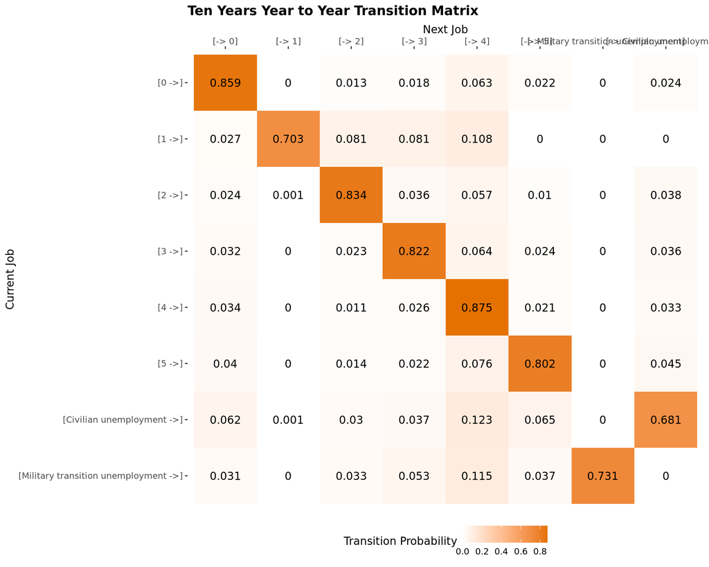

```r
tr <- seqtrate(sts_vet_ten)
gg_transition_matrix(tr, "Ten Years Year to Year Transition Matrix")
```